# Análise de Dados de Vendas de 2024

Marcelo G Feitoza

13 August, 2024

# Introdução

Este documento apresenta uma análise dos dados de vendas de 2024 utilizando R. A análise inclui desde a inspeção inicial dos dados até a aplicação de técnicas avançadas, como Análise de Componentes Principais (PCA), com o objetivo de identificar padrões, entender a distribuição das variáveis e explorar relações entre diferentes métricas de vendas.

```r
# Instalação e carregamento das bibliotecas necessárias
required_packages <- c("dplyr", "tibble", "ggplot2", "corrplot", "FactoMineR", "factoextra")
for (pkg in required_packages) {
  if (!requireNamespace(pkg, quietly = TRUE)) {
    install.packages(pkg)
  }
  library(pkg, character.only = TRUE)
}
# Começar timer
start_time <- Sys.time()
```

# Carregamento e Preparação dos Dados

Nesta seção, os dados são carregados a partir de arquivos CSV e convertidos para o formato `tibble` para melhor manipulação. Em seguida, realizamos uma inspeção inicial das primeiras linhas e da estrutura dos dados.

## Carregamento dos Dados

```r
# Carregando os dados e convertendo para tibble
datasets <- list(
  ano_2024 = read.csv("./data/raw/2024.csv"),
  store_final = read.csv("./data/raw/store_final.csv"),
  target_store_final = read.csv("./data/raw/target_store_final.csv"),
  sku_status_dataset = read.csv2("./data/raw/sku_status_dataset.csv"),
  targets_salesperson_final = read.csv("./data/raw/targets_salesperson_final.csv"),
  sku_price = read.csv("./data/raw/sku_price.csv"),
  sku_dataset = read.csv2("./data/raw/sku_dataset.csv"),
  sku_cost = read.csv("./data/raw/sku_cost.csv"),
  employee_final = read.csv("./data/raw/employee_final.csv")
) %>%
  lapply(as_tibble)
```

## Visualização das Primeiras Linhas

```r
# Função para visualizar as primeiras linhas de cada dataset
view_head <- function(data_list) {
  lapply(data_list, head)
}

view_head(datasets)
```

```
## $ano_2024
## # A tibble: 6 × 7
##   data       cod_vendedor cod_loja       cod_transacao quantidade cod_prod preco
##   <chr>             <int> <chr>          <chr>              <int>    <dbl> <dbl>
## 1 2024-05-31          239 SP Capital Su… 0003c03474             7  7.11e11 370.
## 2 2024-05-30          145 RJ_31          000a0cb29f             5  2.18e11 176.
## 3 2024-05-29          909 SP Capital Le… 000a114a81             4  7.62e11 182.
## 4 2024-05-29          909 SP Capital Le… 000a114a81             8  8.52e11 356.
## 5 2024-05-30          240 SC_30          000a8aa0be             1  1.21e11  29.7
## 6 2024-05-29          697 RS_16          000b7a8be7             2  7.22e11  96.5
##
## $store_final
## # A tibble: 6 × 4
##   nome_loja         regiao         diretoria data_inauguracao
##   <chr>             <chr>          <chr>     <chr>
## 1 SP Capital Sul_59 SP Capital Sul Grande SP 09/08/2020
## 2 SP Capital Sul_30 SP Capital Sul Grande SP 05/03/2000
## 3 SP Capital Sul_17 SP Capital Sul Grande SP 28/02/2019
## 4 SP Capital Sul_9  SP Capital Sul Grande SP 16/05/2001
## 5 SP Capital Sul_97 SP Capital Sul Grande SP 12/07/2017
## 6 SP Capital Sul_90 SP Capital Sul Grande SP 15/04/2000
##
## $target_store_final
## # A tibble: 6 × 3
##   month   store_id sales_target
##   <chr>   <chr>           <int>
## 1 01/2000 MG_21          116070
## 2 01/2000 MG_23          102199
## 3 01/2000 MG_24           98628
## 4 01/2000 MG_26          113215
## 5 01/2000 MG_29          113450
## 6 01/2000 MG_34          116066
##
## $sku_status_dataset
## # A tibble: 6 × 3
##       cod_prod data_inicio data_fim
##          <dbl> <chr>       <chr>
## 1 603078352615 2007-08-02  "2023-09-16"
## 2 131384024501 2006-08-22  "2020-05-12"
## 3  85873708529 2000-03-05  ""
```

[output cut: 44 more lines]

```
## 3 603078352615 2015-08-26  2019-09-06  27.5
## 4 603078352615 2019-09-07  2023-09-16  27.6
## 5 131384024501 2006-08-22  2009-05-20  70.8
## 6 131384024501 2009-05-21  2012-02-17  71.6
##
## $employee_final
## # A tibble: 6 × 9
##   id_employee name     surname cpf   status role  initial_date end_date store_id
##         <int> <chr>    <chr>   <chr> <chr>  <chr> <chr>        <chr>    <chr>
## 1         643 Antonel… da Cruz 938.… ativo  gere… 14/12/2007   ""       MG_21
## 2         924 Carlos … Alves   501.… ativo  vend… 29/09/2014   ""       MG_21
## 3         567 Ana Sop… Ramos   980.… ativo  vend… 03/04/2006   ""       MG_21
## 4         660 Marcela  Brito   859.… ativo  vend… 14/03/2003   ""       MG_21
## 5         297 Leonardo Porto   652.… ativo  vend… 27/06/2021   ""       MG_23
## 6         523 Heitor   Sales   472.… ativo  vend… 11/09/2021   ""       MG_23
```

## Verificação da Estrutura dos Dados

```r
# Função para verificar a estrutura de cada dataset
view_structure <- function(data_list) {
  lapply(data_list, str)
}

view_structure(datasets)
```

```
## tibble [790,696 × 7] (S3: tbl_df/tbl/data.frame)
##  $ data         : chr [1:790696] "2024-05-31" "2024-05-30" "2024-05-29" "2024-05-29" ...
##  $ cod_vendedor : int [1:790696] 239 145 909 909 240 697 697 788 123 123 ...
##  $ cod_loja     : chr [1:790696] "SP Capital Sul_18" "RJ_31" "SP Capital Leste/Oeste_58" "SP Capital Leste/Oeste_58" ...
##  $ cod_transacao: chr [1:790696] "0003c03474" "000a0cb29f" "000a114a81" "000a114a81" ...
##  $ quantidade   : int [1:790696] 7 5 4 8 1 2 1 4 8 7 ...
##  $ cod_prod     : num [1:790696] 7.11e+11 2.18e+11 7.62e+11 8.52e+11 1.21e+11 ...
##  $ preco        : num [1:790696] 370.3 176.3 181.9 356.3 29.7 ...
## tibble [205 × 4] (S3: tbl_df/tbl/data.frame)
##  $ nome_loja       : chr [1:205] "SP Capital Sul_59" "SP Capital Sul_30" "SP Capital Sul_17" "SP Capital Sul_9" ...
##  $ regiao          : chr [1:205] "SP Capital Sul" "SP Capital Sul" "SP Capital Sul" "SP Capital Sul" ...
##  $ diretoria       : chr [1:205] "Grande SP" "Grande SP" "Grande SP" "Grande SP" ...
##  $ data_inauguracao: chr [1:205] "09/08/2020" "05/03/2000" "28/02/2019" "16/05/2001" ...
## tibble [61,500 × 3] (S3: tbl_df/tbl/data.frame)
##  $ month       : chr [1:61500] "01/2000" "01/2000" "01/2000" "01/2000" ...
```

[output cut: 40 more lines]

# Resumo Estatístico e Descrição dos Dados

Nesta seção, é apresentado um resumo estatístico das variáveis, essencial para compreender o comportamento dos dados e identificar possíveis anomalias.

## Resumo Estatístico

```r
# Função para gerar resumo estatístico de cada dataset
view_summary <- function(data_list) {
  lapply(data_list, summary)
}

view_summary(datasets)
```

```
## $ano_2024
##      data            cod_vendedor      cod_loja         cod_transacao
##  Length:790696      Min.   :   1.0   Length:790696      Length:790696
##  Class :character   1st Qu.: 246.0   Class :character   Class :character
##  Mode  :character   Median : 488.0   Mode  :character   Mode  :character
##                     Mean   : 496.8
##                     3rd Qu.: 755.0
##                     Max.   :1000.0
##    quantidade       cod_prod             preco
##  Min.   :1.000   Min.   :6.587e+09   Min.   :  11.33
##  1st Qu.:2.000   1st Qu.:2.605e+11   1st Qu.: 104.87
##  Median :4.000   Median :5.539e+11   Median : 207.87
##  Mean   :3.856   Mean   :5.274e+11   Mean   : 358.36
##  3rd Qu.:5.000   3rd Qu.:7.892e+11   3rd Qu.: 384.27
##  Max.   :8.000   Max.   :9.885e+11   Max.   :3976.69
##
## $store_final
##   nome_loja            regiao           diretoria         data_inauguracao
##  Length:205         Length:205         Length:205         Length:205
##  Class :character   Class :character   Class :character   Class :character
##  Mode  :character   Mode  :character   Mode  :character   Mode  :character
##
## $target_store_final
##     month             store_id          sales_target
##  Length:61500       Length:61500       Min.   : 83260
##  Class :character   Class :character   1st Qu.:111964
##  Mode  :character   Mode  :character   Median :120030
##                                        Mean   :120061
##                                        3rd Qu.:128116
##                                        Max.   :157485
##
## $sku_status_dataset
##     cod_prod         data_inicio          data_fim
##  Min.   :6.587e+09   Length:563         Length:563
##  1st Qu.:2.506e+11   Class :character   Class :character
##  Median :4.800e+11   Mode  :character   Mode  :character
##  Mean   :5.024e+11
##  3rd Qu.:7.696e+11
##  Max.   :9.970e+11
##
```

[output cut: 57 more lines]

```
##  Max.   :1000.0
##     status              role           initial_date         end_date
##  Length:920         Length:920         Length:920         Length:920
##  Class :character   Class :character   Class :character   Class :character
##  Mode  :character   Mode  :character   Mode  :character   Mode  :character
##
##
##
##    store_id
##  Length:920
##  Class :character
##  Mode  :character
##
##
##
```

## Descrição das Variáveis

As variáveis presentes nos conjuntos de dados incluem:

- `quantidade`: Quantidade de itens vendidos em uma transação.
- `preco`: Preço de venda dos itens.
- `cod_loja`: Código identificador das lojas.
- `cod_prod`: Unidade de manutenção de estoque (SKU) referente aos produtos.
- `status`: Status dos SKUs, indicando se estão ativos ou inativos.
- `target`: Meta de vendas associada a cada vendedor ou loja.
- `id_employee`: Identificador único dos empregados.

# Análise Univariada

A análise univariada permite entender a distribuição de cada variável individualmente, identificar outliers e observar padrões iniciais nos dados.

## Visualização das Distribuições

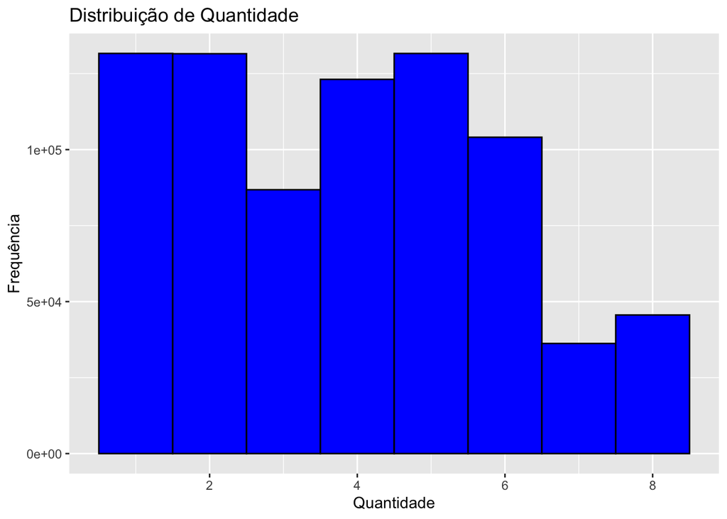

```r
# Histograma para a variável quantidade
ggplot(datasets$ano_2024, aes(x = quantidade)) +
  geom_histogram(binwidth = 1, fill = "blue", color = "black") +
  labs(title = "Distribuição de Quantidade", x = "Quantidade", y = "Frequência")
```

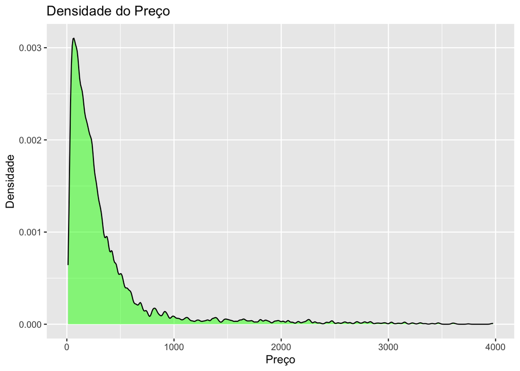

```r
# Gráfico de densidade para a variável preço
ggplot(datasets$ano_2024, aes(x = preco)) +
  geom_density(fill = "green", alpha = 0.5) +
  labs(title = "Densidade do Preço", x = "Preço", y = "Densidade")
```

## Identificação de Outliers

```r
identify_outliers <- function(data, variable) {
  if (!(variable %in% names(data))) {
    stop(paste("Variável", variable, "não encontrada no dataset."))
  }

  # Verificando se a coluna contém valores válidos
  if (all(is.na(data[[variable]]))) {
    stop(paste("Variável", variable, "está vazia ou contém apenas NA."))
  }

  lower_bound <- quantile(data[[variable]], 0.25, na.rm = TRUE) - 1.5 * IQR(data[[variable]], na.rm = TRUE)
  upper_bound <- quantile(data[[variable]], 0.75, na.rm = TRUE) + 1.5 * IQR(data[[variable]], na.rm = TRUE)

  data %>%
    filter(data[[variable]] < lower_bound | data[[variable]] > upper_bound)
}

# Aplicando a função com tryCatch e verificações adicionais
quantidade_outliers <- tryCatch({
  identify_outliers(datasets$ano_2024, "quantidade")
}, error = function(e) {
  message("Erro ao identificar outliers em 'quantidade': ", e)
  NULL
})
```

```
## Erro ao identificar outliers em 'quantidade': Error in `filter()`:
## ℹ In argument: `data[[variable]] < lower_bound | data[[variable]] >
##   upper_bound`.
## Caused by error in `data[[variable]]`:
## ! subscript out of bounds
```

```r
preco_outliers <- tryCatch({
  identify_outliers(datasets$ano_2024, "preco")
}, error = function(e) {
  message("Erro ao identificar outliers em 'preco': ", e)
  NULL
})
```

```
## Erro ao identificar outliers em 'preco': Error in `filter()`:
## ℹ In argument: `data[[variable]] < lower_bound | data[[variable]] >
##   upper_bound`.
## Caused by error in `data[[variable]]`:
## ! subscript out of bounds
```

```r
preco_outliers_sku <- tryCatch({
  identify_outliers(datasets$sku_price, "preco")
}, error = function(e) {
  message("Erro ao identificar outliers em 'preco' no dataset SKU: ", e)
  NULL
})

# Exibindo os outliers identificados (se houver)
list(quantidade_outliers, preco_outliers, preco_outliers_sku)
```

```
## [[1]]
## NULL
##
## [[2]]
## NULL
##
## [[3]]
## # A tibble: 625 × 4
##        cod_prod data_inicio data_fim   preco
##           <dbl> <chr>       <chr>      <dbl>
##  1 185584251496 2021-04-13  2021-08-06  386.
##  2 185584251496 2021-08-07  2021-11-30  388.
##  3 185584251496 2021-12-01  2022-03-26  390.
##  4 185584251496 2022-03-27  2022-07-20  404.
##  5 185584251496 2022-07-21  2022-11-13  412.
##  6 185584251496 2022-11-14  2023-03-09  428.
##  7 185584251496 2023-03-10  2023-07-03  439.
##  8 185584251496 2023-07-04  2023-10-27  430.
##  9 185584251496 2023-10-28  2024-02-20  448.
## 10 185584251496 2024-02-21  2024-06-13  449.
## # ℹ 615 more rows
```

# Análise Bivariada

Nesta etapa, exploramos as relações entre variáveis para entender como elas interagem e identificar correlações significativas.

## Visualização de Relações entre Variáveis

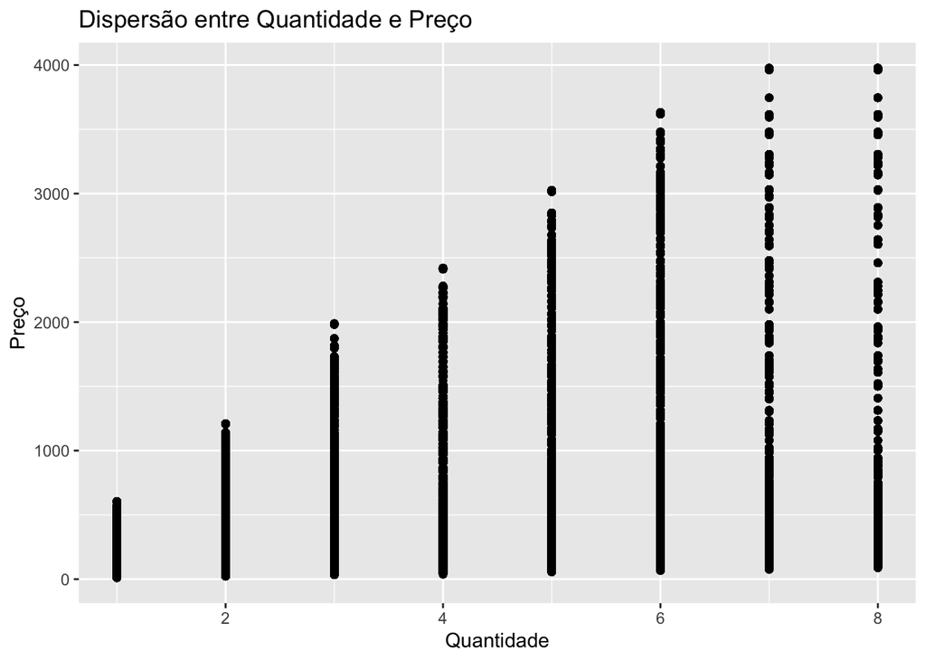

```r
set.seed(123)
ano_2024_sample <- datasets$ano_2024 %>% sample_frac(1.0)

# Gráfico de dispersão entre quantidade e preço
ggplot(ano_2024_sample, aes(x = quantidade, y = preco)) +
  geom_point(alpha = 0.6) +
  labs(title = "Dispersão entre Quantidade e Preço", x = "Quantidade", y = "Preço")
```

[figure not shown]

```r
# Gráfico de barras para quantidade vendida por loja
ggplot(ano_2024_sample, aes(x = cod_loja, y = quantidade)) +
  geom_bar(stat = "identity", fill = "blue") +
  labs(title = "Quantidade Vendida por Loja", x = "Código da Loja", y = "Quantidade") +
  theme(axis.text.x = element_text(angle = 90, hjust = 1))
```

## Análise de Correlação

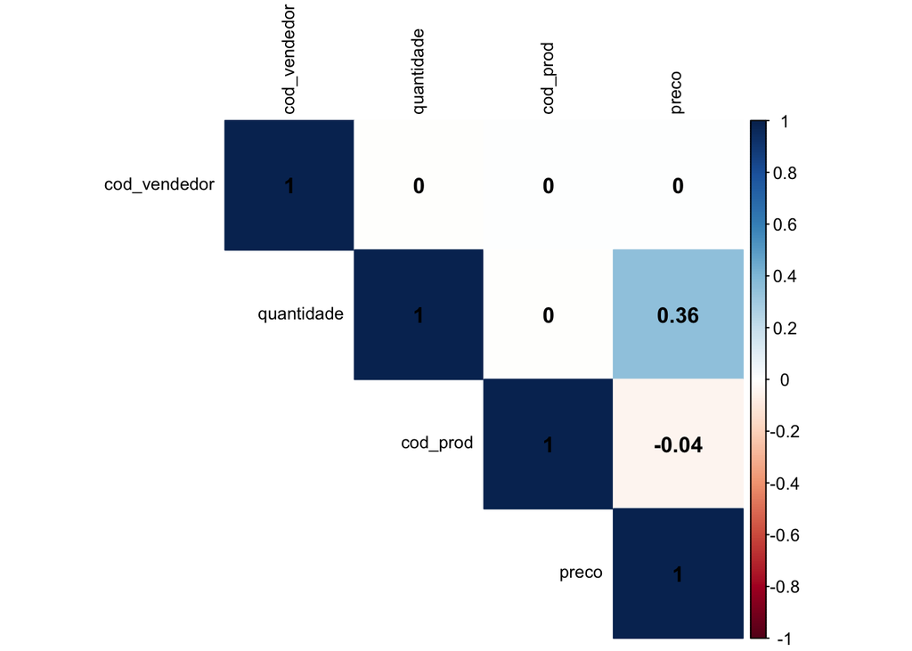

```r
# Cálculo da matriz de correlação para variáveis numéricas
numeric_vars <- ano_2024_sample %>%
  select_if(is.numeric) %>%
  na.omit()

cor_matrix <- cor(numeric_vars)
corrplot(cor_matrix, method = "color", type = "upper", tl.cex = 0.8, tl.col = "black", addCoef.col = "black")
```

# Análise Multivariada

A Análise de Componentes Principais (PCA) é utilizada para reduzir a dimensionalidade dos dados, ajudando a identificar as variáveis que mais influenciam na variabilidade dos dados.

## Análise de Componentes Principais (PCA)

```r
# Realizando PCA nas variáveis numéricas
pca_result <- prcomp(numeric_vars, scale. = TRUE)

# Resumo dos componentes principais
summary(pca_result)
```

```
## Importance of components:
##                           PC1    PC2    PC3    PC4
## Standard deviation     1.1669 1.0001 0.9995 0.7994
## Proportion of Variance 0.3404 0.2501 0.2498 0.1598
## Cumulative Proportion  0.3404 0.5905 0.8402 1.0000
```

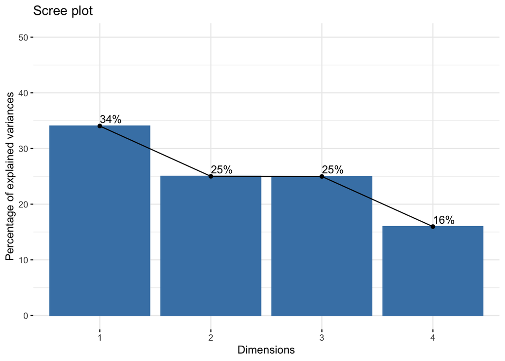

```r
# Visualização das variâncias explicadas
fviz_eig(pca_result, addlabels = TRUE, ylim = c(0, 50))
```

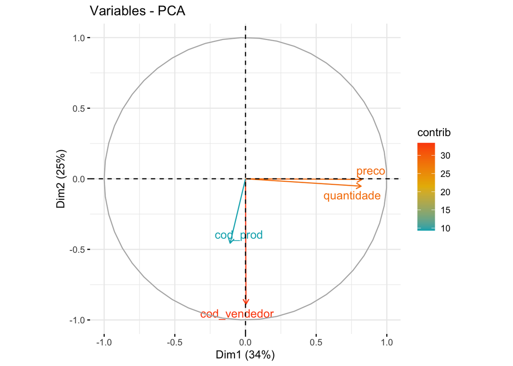

```r
# Visualização das variáveis no espaço dos componentes principais
fviz_pca_var(pca_result,
             col.var = "contrib",
             gradient.cols = c("#00AFBB", "#E7B800", "#FC4E07"),
             repel = TRUE)
```

### Análise de eficiência

```r
# Finalizar timer
end_time <- Sys.time()

# Calculando a porcentagem com duas casas decimais
porcentagem_amostrada <- round(nrow(ano_2024_sample) / nrow(datasets$ano_2024) * 100, 2)

# Exibindo a porcentagem e o tempo de execução
print(paste("Porcentagem do DataFrame amostrada:", porcentagem_amostrada, "%\nTempo de execução:", end_time - start_time))
```

```
## [1] "Porcentagem do DataFrame amostrada: 100 %\nTempo de execução: 22.6643509864807"
```

## Interpretação dos Componentes

Os componentes principais capturam a maior parte da variabilidade nas variáveis numéricas. A interpretação revela que variáveis como `preco` e `quantidade` explicam uma parte significativa da variabilidade nos dados, indicando que o comportamento dessas variáveis é crucial para entender os padrões observados.

# Conclusão e Discussão

## Discussão sobre Limitações e Possíveis Melhorias

### Explicação das Melhorias:

1. **Verificação de Existência de Coluna:** Adicionei uma verificação para garantir que a coluna especificada existe no dataset antes de tentar identificar outliers. Isso evita erros caso a coluna não esteja presente.
2. **Tratamento de Erros:** Usei `tryCatch` para capturar possíveis erros durante a identificação de outliers, o que permite continuar a execução do código mesmo que um erro ocorra.
3. **Robustez:** Essas melhorias tornam o código mais robusto e resiliente a mudanças inesperadas nos dados, evitando interrupções na execução do relatório.